# Matched pairs

## Matched pairs

Some data:

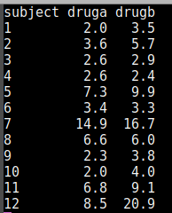

## Matched pairs 1/2

- Data are comparison of 2 drugs for effectiveness at reducing pain.
  - 12 subjects (cases) were arthritis sufferers
  - Response is #hours of pain relief from each drug.
- In reading example, each child tried only one reading method.
- But here, each subject tried out both drugs, giving us two measurements.
- Possible because, if you wait long enough, one drug has no influence over effect of other.

## Matched pairs 2/2

- Advantage: focused comparison of drugs. Compare one drug with another on same person, removes a lot of variability due to differences between people.
- Matched pairs, requires different analysis.
- Design: randomly choose 6 of 12 subjects to get drug A first, other 6 get drug B first.

## Packages

```r
library(tidyverse)
library(smmr) # for a sign test later
```

## Reading the data

Values aligned in columns:

```r
my_url <- "http://ritsokiguess.site/datafiles/analgesic.txt"
pain <- read_table(my_url)
pain
```

| subject | druga | drugb |
| --- | --- | --- |
| 1 | 2.0 | 3.5 |
| 2 | 3.6 | 5.7 |
| 3 | 2.6 | 2.9 |
| 4 | 2.6 | 2.4 |
| 5 | 7.3 | 9.9 |
| 6 | 3.4 | 3.3 |
| 7 | 14.9 | 16.7 |
| 8 | 6.6 | 6.0 |
| 9 | 2.3 | 3.8 |
| 10 | 2.0 | 4.0 |

[output cut: 2 more lines]

## Paired $t$-test

```r
with(pain, t.test(druga, drugb, paired = TRUE))
```

```
    Paired t-test

data:  druga and drugb
t = -2.1677, df = 11, p-value = 0.05299
alternative hypothesis: true mean difference is not equal to 0
95 percent confidence interval:
 -4.29941513  0.03274847
sample estimates:
mean difference
      -2.133333
```

- P-value is 0.053.
- Not quite evidence of difference between drugs.

## t-testing the differences

- Or, calculate the differences yourself and then do a 1-sample t-test on them.

```r
pain %>% mutate(diff = druga - drugb) -> pain
pain
```

| subject | druga | drugb | diff |
| --- | --- | --- | --- |
| 1 | 2.0 | 3.5 | -1.5 |
| 2 | 3.6 | 5.7 | -2.1 |
| 3 | 2.6 | 2.9 | -0.3 |
| 4 | 2.6 | 2.4 | 0.2 |
| 5 | 7.3 | 9.9 | -2.6 |
| 6 | 3.4 | 3.3 | 0.1 |
| 7 | 14.9 | 16.7 | -1.8 |
| 8 | 6.6 | 6.0 | 0.6 |
| 9 | 2.3 | 3.8 | -1.5 |
| 10 | 2.0 | 4.0 | -2.0 |

[output cut: 2 more lines]

## t-test on the differences

- then throw them into t.test, testing that the mean is zero, with same result as before:

```r
with(pain, t.test(diff, mu = 0))
```

```
    One Sample t-test

data:  diff
t = -2.1677, df = 11, p-value = 0.05299
alternative hypothesis: true mean is not equal to 0
95 percent confidence interval:
 -4.29941513  0.03274847
sample estimates:
mean of x
-2.133333
```

- Same P-value (0.053) and conclusion.

## Assessing normality

- 1-sample and 2-sample t-tests assume (each) group normally distributed.
- Matched pairs analyses assume (theoretically) that differences normally distributed.
- How to assess normality? A normal quantile plot.

## The normal quantile plot (of differences)

```r
ggplot(pain,aes(sample=diff))+stat_qq()+stat_qq_line()
```

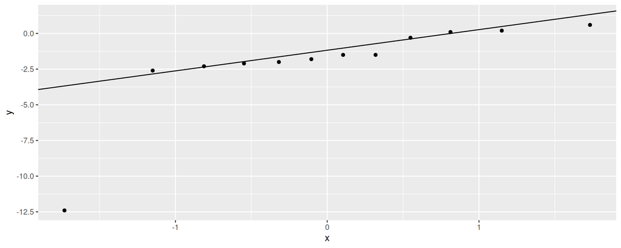

- Points should follow the straight line. Bottom left one way off, so normality questionable here: outlier.

## What to do instead?

- Matched pairs $t$-test based on one sample of differences
- the differences not normal (enough)
- so do *sign test* on differences, null median 0:

```r
sign_test(pain, diff, 0)
```

```
$above_below
below above
    9     3

$p_values
  alternative    p_value
1       lower 0.07299805
2       upper 0.98071289
3   two-sided 0.14599609
```

## Did we need to worry about that outlier?

Bootstrap sampling distribution of sample mean differences:

```r
tibble(sim = 1:10000) %>%
  rowwise() %>%
  mutate(my_sample = list(sample(pain$diff, replace = TRUE))) %>%
  mutate(my_mean = mean(my_sample)) %>%
  ggplot(aes(sample = my_mean)) + stat_qq() + stat_qq_line()
```

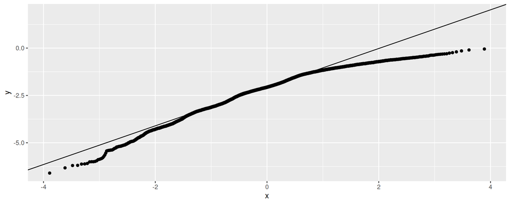

Yes we did; this is clearly skewed left and not normal.

## Comments

- no evidence of any difference between drugs (P-value 0.1460)
- in $t$-test, the low outlier difference pulled mean difference downward and made it look more negative than it should have been
- therefore, there really isn’t any difference between the drugs.